# Problem Set 4: RDD

Romu Meango

MT 2025

# Regression Discontinuity Design

Lee (2008) is a well cited example of RDD. It looks at the effect of incumbency on the chance of being reelected. The data are for the house of representatives in the US.

Have a go at performing each step of a regular RDD estimation. We will use local polynomial regression tool.

You will need the library `rddtools`.

1. You can access the dataset `house` from the package `rddtools` Rename the variables `x`, `margin_win` and `y`,`share_vote`

```r
library(dplyr)
library(ggplot2)
library(rddtools)
library(magrittr)
library(haven)
library(tidyverse)
library(broom)

data(house)
house<- house %>%
  rename(margin_win = x,share_vote=y)

## ---- Define data as RDD compatible
rdd_house <- rdd_data(x=margin_win, y=share_vote, data=house, cutpoint=0)
```

2. Slice the running variable (`margin_win`) in 400 bins, and average the outcome variable (`share_vote`) over these bins. Draw a scatter plot of the average outcome variable in each bin as a function of the running variable. Can you spot the discontinuity?

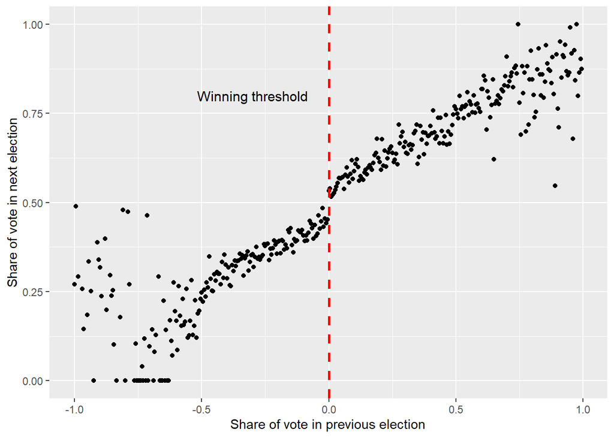

```r
  rddhouse<- house %>%
  mutate(bin_margin_win = cut(margin_win, breaks=400)) %>%
  mutate(bin_margin_win = as.numeric( sub("\\((.+),.*", "\\1", bin_margin_win) ))%>% # Extract the lower point as value
  group_by(bin_margin_win) %>%
  summarise(mean_share_vote= mean(share_vote),pdf_margin_win = n())


# RDD plot - Share of vote next election by share of vote in previous election
rddhouse %>%
  ggplot(aes(x = bin_margin_win, y = mean_share_vote)) +
  geom_point() +
  geom_vline(xintercept = 0, color = "red", linewidth = 1, linetype = "dashed") +
  annotate("text", x = -0.3, y = 0.80, label = "Winning threshold",
           size=4) +
  labs(y = "Share of vote in next election",
       x = "Share of vote in previous election")
```

A slight discontinuty is discernable. It is conveniently at 0! Let’s make it more visible!

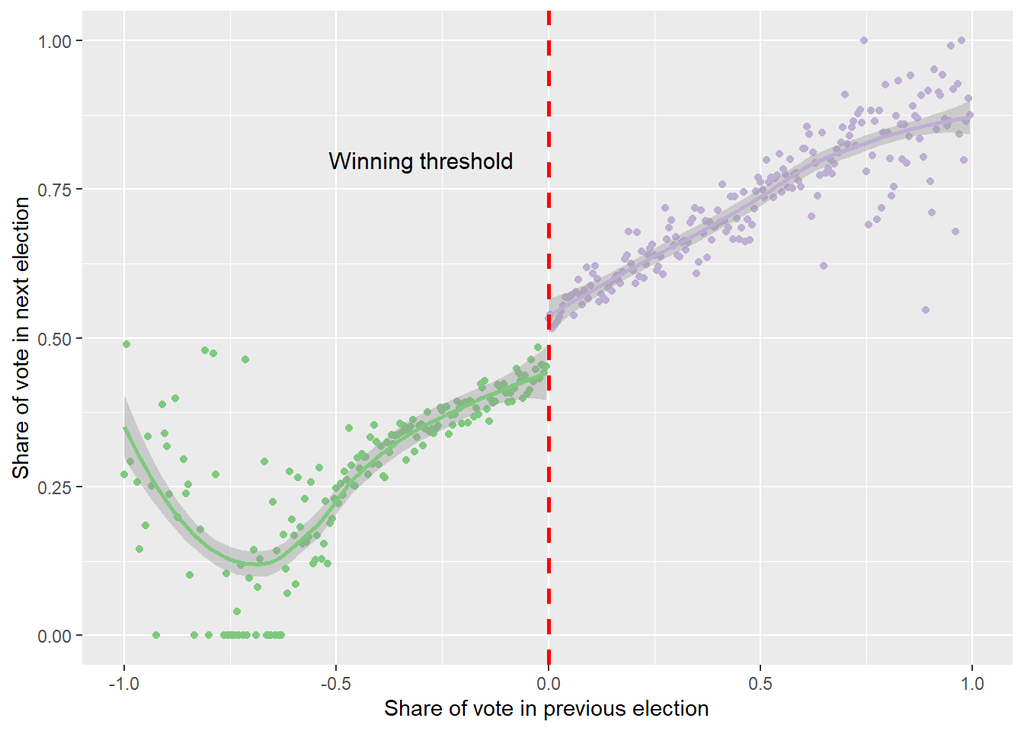

```r
rddhouse %>%
  mutate(threshold = as.factor(ifelse(bin_margin_win >= 0, 1, 0))) %>%
  ggplot(aes(x = bin_margin_win, y = mean_share_vote, color = threshold)) +
  geom_point() +
  geom_smooth(method = "loess", se = TRUE) +
  scale_color_brewer(palette = "Accent") +
  guides(color = FALSE) +
  geom_vline(xintercept = 0, color = "red", linewidth = 1, linetype = "dashed") +
  annotate("text", x = -0.3, y = 0.80, label = "Winning threshold",
           size=4) +
  labs(y = "Share of vote in next election",
       x = "Share of vote in previous election")
```

3. Estimate the density of the running variable `margin_win`, separately on the right and on the left. Does it seems to have any discontinuity?

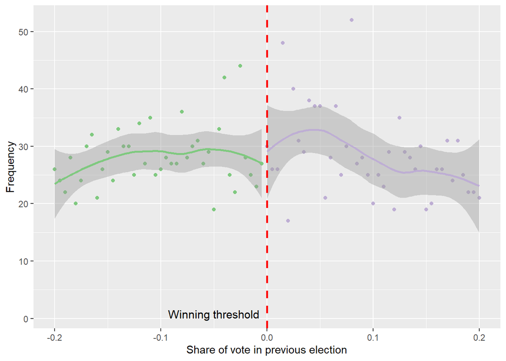

```r
## Graphical representation of density of running variable
rddhouse %>%
  mutate(threshold = as.factor(ifelse(bin_margin_win >= 0, 1, 0))) %>%
  filter(bin_margin_win>= -0.2 & bin_margin_win<= 0.2)%>%
  ggplot(aes(x = bin_margin_win, y =pdf_margin_win, color = threshold)) +
  geom_point() +
  geom_smooth(method = "loess", se = TRUE) +
  scale_color_brewer(palette = "Accent") +
  guides(color = "none") +
  geom_vline(xintercept = 0, color = "red", linewidth = 1, linetype = "dashed") +
  annotate("text", x = -0.05, y = 0.80, label = "Winning threshold",
           size=4) +
  labs(y = "Frequency",
       x = "Share of vote in previous election")
```

Reassuringly, there is no discernable discontinuity.

4. Use the `R`-package `rddtools` to perform the estimation of the causal effect, with a linear, then a quadratic model.

```r
## With RDD tools
rdd_house %>%
  rdd_reg_lm(slope = "same") %>%
  summary()
```

```
##
## Call:
## lm(formula = y ~ ., data = dat_step1, weights = weights)
##
## Residuals:
##      Min       1Q   Median       3Q      Max
## -0.88700 -0.06324  0.00027  0.07082  0.88780
##
## Coefficients:
##             Estimate Std. Error t value Pr(>|t|)
## (Intercept) 0.442736   0.003168  139.75   <2e-16 ***
## D           0.113728   0.005528   20.57   <2e-16 ***
## x           0.330533   0.005989   55.19   <2e-16 ***
## ---
## Signif. codes:  0 '***' 0.001 '**' 0.01 '*' 0.05 '.' 0.1 ' ' 1
##
## Residual standard error: 0.1385 on 6555 degrees of freedom
## Multiple R-squared:  0.6701, Adjusted R-squared:   0.67
## F-statistic:  6658 on 2 and 6555 DF,  p-value: < 2.2e-16
```

```r
rdd_house %>%
  rdd_reg_lm(slope = "separate") %>%
  summary()
```

```
##
## Call:
## lm(formula = y ~ ., data = dat_step1, weights = weights)
##
## Residuals:
##      Min       1Q   Median       3Q      Max
## -0.89406 -0.06189  0.00231  0.07129  0.86396
##
## Coefficients:
##             Estimate Std. Error t value Pr(>|t|)
## (Intercept) 0.432948   0.004276 101.254  < 2e-16 ***
## D           0.118231   0.005680  20.816  < 2e-16 ***
## x           0.296906   0.011546  25.714  < 2e-16 ***
## x_right     0.045978   0.013501   3.405 0.000665 ***
## ---
## Signif. codes:  0 '***' 0.001 '**' 0.01 '*' 0.05 '.' 0.1 ' ' 1
##
## Residual standard error: 0.1384 on 6554 degrees of freedom
## Multiple R-squared:  0.6707, Adjusted R-squared:  0.6706
## F-statistic:  4450 on 3 and 6554 DF,  p-value: < 2.2e-16
```

```r
# Quadratic model
rdd_house %>%
  rdd_reg_lm(slope = "separate",order = 2) %>%
  summary()
```

```
##
## Call:
## lm(formula = y ~ ., data = dat_step1, weights = weights)
##
## Residuals:
##      Min       1Q   Median       3Q      Max
## -0.87978 -0.06054  0.00256  0.06936  0.77355
##
## Coefficients:
##              Estimate Std. Error t value Pr(>|t|)
## (Intercept)  0.478338   0.005930  80.658  < 2e-16 ***
## D            0.051869   0.008087   6.414 1.52e-10 ***
## x            0.631845   0.032731  19.304  < 2e-16 ***
## `x^2`        0.379957   0.034797  10.919  < 2e-16 ***
## x_right     -0.155101   0.042351  -3.662 0.000252 ***
## `x^2_right` -0.507126   0.042654 -11.889  < 2e-16 ***
## ---
## Signif. codes:  0 '***' 0.001 '**' 0.01 '*' 0.05 '.' 0.1 ' ' 1
##
## Residual standard error: 0.1369 on 6552 degrees of freedom
## Multiple R-squared:  0.6779, Adjusted R-squared:  0.6776
## F-statistic:  2758 on 5 and 6552 DF,  p-value: < 2.2e-16
```

5. Perform a robustness test by restricting the running variable between -0.1 and 0.1.

```r
# Sensitivity check
rdd_house %>%
  filter(x>= -0.1 & x<= 0.1)%>%
  rdd_reg_lm(slope = "separate",order = 1) %>%
  summary()
```

```
##
## Call:
## lm(formula = y ~ ., data = dat_step1, weights = weights)
##
## Residuals:
##      Min       1Q   Median       3Q      Max
## -0.56009 -0.05455 -0.00635  0.04262  0.47210
##
## Coefficients:
##             Estimate Std. Error t value Pr(>|t|)
## (Intercept) 0.464015   0.009389  49.419  < 2e-16 ***
## D           0.060579   0.012994   4.662 3.48e-06 ***
## x           0.644045   0.163125   3.948 8.33e-05 ***
## x_right     0.004893   0.225778   0.022    0.983
## ---
## Signif. codes:  0 '***' 0.001 '**' 0.01 '*' 0.05 '.' 0.1 ' ' 1
##
## Residual standard error: 0.111 on 1205 degrees of freedom
## Multiple R-squared:  0.2575, Adjusted R-squared:  0.2557
## F-statistic: 139.3 on 3 and 1205 DF,  p-value: < 2.2e-16
```

6. Perform a placebo test by setting running variable at -0.1.

```r
rdd_house_sensitivity <- rdd_data(x=margin_win, y=share_vote, data=house, cutpoint=-0.1)

rdd_house_sensitivity %>%
  filter(x>= -0.2 & x<= 0.0)%>%
  rdd_reg_lm(slope =  "separate",order = 1) %>%
  summary()
```

```
##
## Call:
## lm(formula = y ~ ., data = dat_step1, weights = weights)
##
## Residuals:
##      Min       1Q   Median       3Q      Max
## -0.45113 -0.04504  0.00366  0.05013  0.60308
##
## Coefficients:
##              Estimate Std. Error t value Pr(>|t|)
## (Intercept)  0.412910   0.008658  47.692   <2e-16 ***
## D           -0.013300   0.012305  -1.081   0.2800
## x            0.343821   0.155074   2.217   0.0268 *
## x_right      0.300224   0.217435   1.381   0.1676
## ---
## Signif. codes:  0 '***' 0.001 '**' 0.01 '*' 0.05 '.' 0.1 ' ' 1
##
## Residual standard error: 0.1037 on 1119 degrees of freedom
## Multiple R-squared:  0.04711,    Adjusted R-squared:  0.04455
## F-statistic: 18.44 on 3 and 1119 DF,  p-value: 1.113e-11
```

# Fuzzy RDD: An example

In this example, students take an entrance exam at the beginning of a school year. Those who score 70 are offered a free tutoring program and assistance throughout the year. At the end of the school year, students take a final test, or exit exam (with a maximum of 100 points) to measure how much they learned overall.

The data is available here: https://evalf20.classes.andrewheiss.com/data/tutoring_program_fuzzy.csv. The running variable is `entrance_exam`. The treatment is `tutoring`. The outcome is `exit_exam`.

1. Check that we have indeed a Fuzzy RDD.

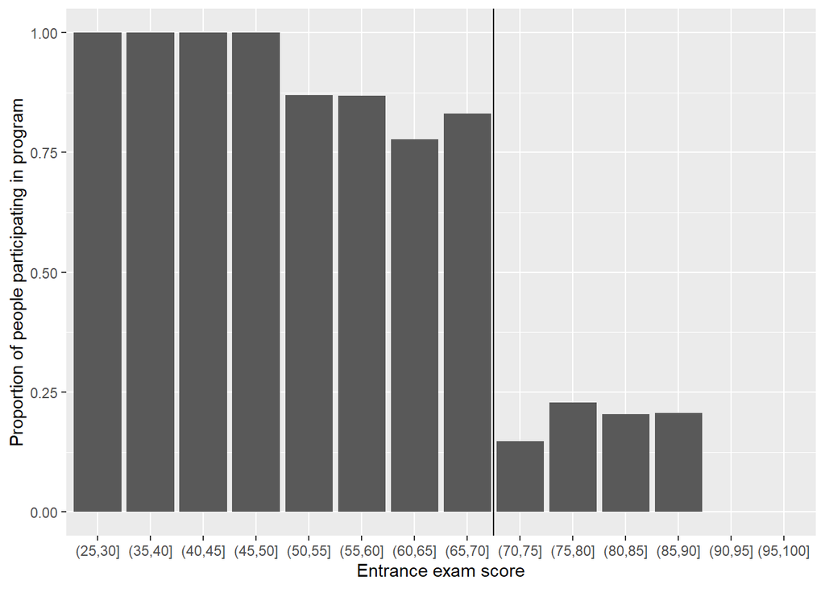

```r
library(tidyverse)  # ggplot(), %>%, mutate(), and friends
library(broom)  # Convert models to data frames
library(rdrobust)  # For robust nonparametric regression discontinuity
library(estimatr)  # Run 2SLS models in one step with iv_robust()
library(modelsummary)  # Create side-by-side regression tables
library(kableExtra)  # Fancy table formatting

tutoring <- read_csv("C:/Users/econ0613/OneDrive - Nexus365/3_Teaching/Datasets/tutoring_program_fuzzy.csv")

# This code uses cut() to split the entrance exam column into distinct
# categories (0-5, 5-10, 10-15, etc.).
tutoring_with_bins <- tutoring %>%
  mutate(exam_binned = cut(entrance_exam, breaks = seq(0, 100, 5))) %>%
  # Group by each of the new bins and tutoring status
  group_by(exam_binned, tutoring) %>%
  # Count how many people are in each test bin + used/didn't use tutoring
  summarize(n = n()) %>%
  # Make this summarized data wider so that there's a column for tutoring and no tutoring
  pivot_wider(names_from = "tutoring", values_from = "n", values_fill = 0) %>%
  rename(tutor_yes = `TRUE`, tutor_no = `FALSE`) %>%
  # Find the probability of tutoring in each bin by taking
  # the count of yes / count of yes + count of no
  mutate(prob_tutoring = tutor_yes / (tutor_yes + tutor_no))

# Plot the hsitogram
ggplot(tutoring_with_bins, aes(x = exam_binned, y = prob_tutoring)) +
  geom_col() +
  geom_vline(xintercept = 8.5) +
  labs(x = "Entrance exam score", y = "Proportion of people participating in program")
```

If this were a sharp design, every single bar to the left of the cutpoint would be 100% and every single bar to the right would be 0%, but that’s not the case here. The probability of tutoring changes at the cutpoint, but it’s not 100% perfect.

2. Center the running variable around the cut-off and estimate the treatment effect on the Fuzzy RDD compliers by a 2SLS-regression. You can use the `ivrobust()` from the `estimatr` package.

```r
tutoring_centered <- tutoring %>%
  mutate(entrance_centered = entrance_exam - 70,
         below_cutoff = entrance_exam <= 70)
tutoring_centered
```

```
## # A tibble: 1,000 x 7
##       id entrance_exam tutoring tutoring_text exit_exam entrance_centered
##    <dbl>         <dbl> <lgl>    <chr>             <dbl>             <dbl>
##  1     1          92.4 FALSE    No tutor           78.1            22.4
##  2     2          72.8 FALSE    No tutor           58.2             2.77
##  3     3          53.7 TRUE     Tutor              62.0           -16.3
##  4     4          98.3 FALSE    No tutor           67.5            28.3
##  5     5          69.7 TRUE     Tutor              54.1            -0.288
##  6     6          68.1 TRUE     Tutor              60.1            -1.93
##  7     7          86.0 FALSE    No tutor           73.1            16.0
##  8     8          85.7 TRUE     Tutor              76.7            15.7
##  9     9          85.9 FALSE    No tutor           57.8            15.9
## 10    10          89.5 FALSE    No tutor           79.9            19.5
## # ... with 990 more rows, and 1 more variable: below_cutoff <lgl>
```

The 2SLS equation is:
$$\begin{eqnarray}
\text{Exit_exam} &=& \beta_0 + \beta_1 \text{Entrance_centered} + \beta_2 \text{Tutoring} + v,\\
\text{Tutoring} &=& \gamma_0 + \gamma_1 \text{Entrance_centered} + \gamma_2 I \{\text{Entrance_exam} < 70\} + u
\end{eqnarray}$$
The cut-off $ below_cutoff:= I {{Entrance_exam < 70}} $ serves as an instrument for the endogenous variable $\text{Tutoring}$.

```r
model_fuzzy <- iv_robust(
  exit_exam ~ entrance_centered + tutoring | entrance_centered + below_cutoff,
  data = filter(tutoring_centered, entrance_centered >= -10 & entrance_centered <= 10)
)
tidy(model_fuzzy)
```

```
##                term   estimate  std.error statistic       p.value   conf.low
## 1       (Intercept) 60.1413558 1.01765573 59.097939 9.746624e-200 58.1407338
## 2 entrance_centered  0.4366281 0.09929619  4.397229  1.407213e-05  0.2414205
## 3      tutoringTRUE  9.7410444 1.91184891  5.095091  5.384163e-07  5.9825170
##    conf.high  df   outcome
## 1 62.1419778 400 exit_exam
## 2  0.6318357 400 exit_exam
## 3 13.4995718 400 exit_exam
```

```r
b <- summary(model_fuzzy)$coefficients["tutoringTRUE","Estimate"]
```

Tutoring program causes an average increase of 9.7410444 points on the final exam for compliers in the bandwidth.

We can try with a different bandwidth.

```r
model_fuzzy <- iv_robust(
  exit_exam ~ entrance_centered + tutoring | entrance_centered + below_cutoff,
  data = filter(tutoring_centered, entrance_centered >= -15 & entrance_centered <= 15)
)
tidy(model_fuzzy)
```

```
##                term   estimate  std.error statistic       p.value   conf.low
## 1       (Intercept) 60.2180667 0.88998295 67.662045 1.310816e-281 58.4701767
## 2 entrance_centered  0.4069769 0.06081466  6.692085  5.089114e-11  0.2875394
## 3      tutoringTRUE  9.2799261 1.66221078  5.582882  3.599225e-08  6.0154123
##    conf.high  df   outcome
## 1 61.9659567 595 exit_exam
## 2  0.5264144 595 exit_exam
## 3 12.5444399 595 exit_exam
```

```r
b <- summary(model_fuzzy)$coefficients["tutoringTRUE","Estimate"]
```

The estimated effect is robust, 9.2799261.

3. Use the Package `rdrobust` to estimate the treatment effect of interest.

```r
rdrobust(y = tutoring$exit_exam, x = tutoring$entrance_exam,
         c = 70, fuzzy = tutoring$tutoring) %>%
  summary()
```

```
## Fuzzy RD estimates using local polynomial regression.
##
## Number of Obs.                 1000
## BW type                       mserd
## Kernel                   Triangular
## VCE method                       NN
##
## Number of Obs.                  238          762
## Eff. Number of Obs.             170          347
## Order est. (p)                    1            1
## Order bias  (q)                   2            2
## BW est. (h)                  12.985       12.985
## BW bias (b)                  19.733       19.733
## rho (h/b)                     0.658        0.658
## Unique Obs.                     238          762
##
## First-stage estimates.
##
## =============================================================================
##         Method     Coef. Std. Err.         z     P>|z|      [ 95% C.I. ]
## =============================================================================
##   Conventional    -0.708     0.073    -9.751     0.000    [-0.850 , -0.565]
##         Robust         -         -    -8.424     0.000    [-0.907 , -0.565]
## =============================================================================
##
## Treatment effect estimates.
##
## =============================================================================
##         Method     Coef. Std. Err.         z     P>|z|      [ 95% C.I. ]
## =============================================================================
##   Conventional     9.683     1.893     5.116     0.000     [5.973 , 13.393]
##         Robust         -         -     4.258     0.000     [5.210 , 14.095]
## =============================================================================
```

# Regression Kink Design

This question explores the Regression Kink Design (RKD hereafter), a research design very close to both Instrument Variable (IV) and Regression Discontinuity Design (RDD), covered during the lecture. The tools that we have developed during the lecture will help you solve this problem.

1. First, think of a continuous treatment $D$. In this case, which parameter would be an equivalent to the average treatment effect that was defined in the binary case? Do you have a real-life example of such setup?
2. RKD usually deals with a continuous treatment $D$. The intensity of the treatment depends on a running variable $X$, that is $D = D(X)$. The slope of the mapping $D: x \mapsto D(x)$ changes abruptly beyond a given threshold $c$.

The usual estimand is:
$$\tau_{RKD} \equiv \frac{ \lim_{x \downarrow c} \dfrac{\partial\mathbb{E}[Y|X = x]}{\partial x} - \lim_{x \uparrow c}\dfrac{\partial \mathbb{E}[Y|X = x]}{\partial x}}{\lim_{x \downarrow c} \dfrac{\partial D(x) }{\partial x} - \lim_{x \uparrow c}\dfrac{\partial D(x)}{\partial x}}.$$
Taking inspiration from the Wald estimand and the LATE estimator, can you interpret: (i) The numerator, (ii) the denominator, (iii) the ratio?

3. Which aggregate treatment effect is identified from $\tau_{RKD}$? Which assumption(s) is (are) needed?
4. The following graphs represent a “sharp RKD” and a “Fuzzy RKD”. Comment on the difference. Would you be able to use any of these design with a binary variable $D$?

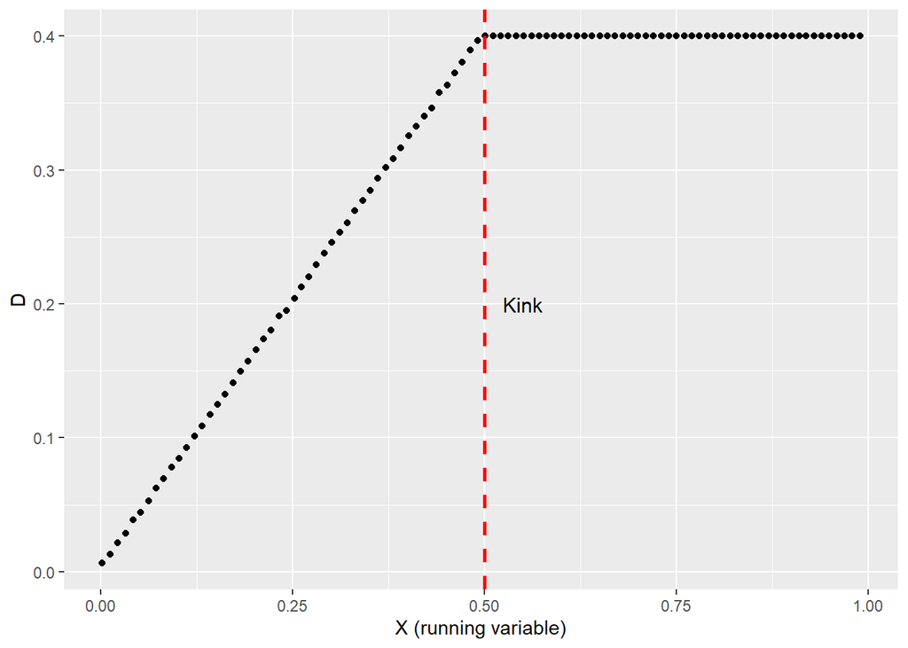

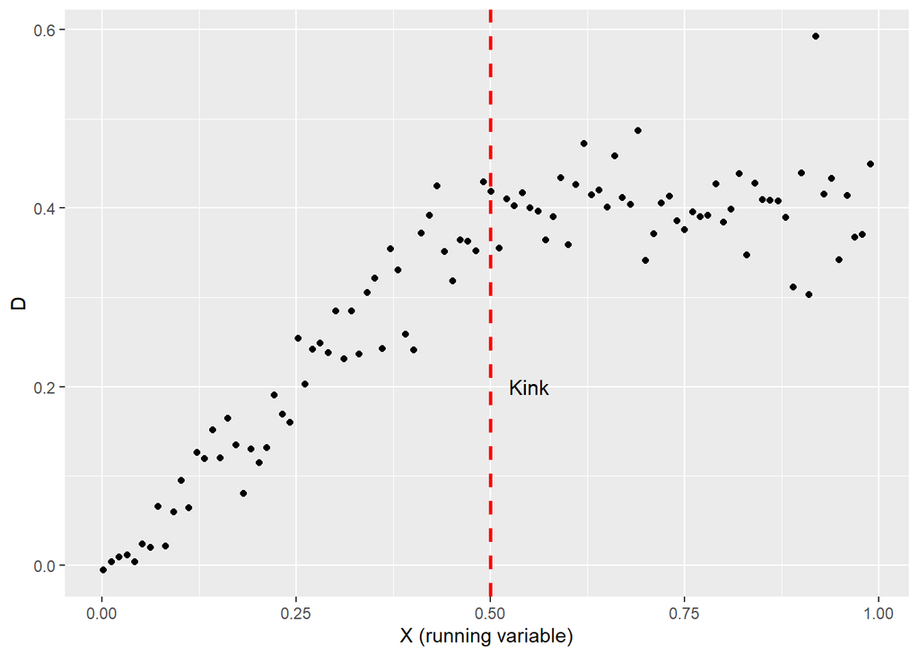

5. How would you modify $\tau_{RKD}$ in the fuzzy RKD framework? Which aggregate treatment effect would be identified from your suggestion, say $\tau_{FRKD}$? Which assumption(s) is (are) needed?
6. Lundqvist, Dahlberg, and Mork (2014) analyse the effect of intergovernmental grants on local public employment. You can find the paper here: https://www.aeaweb.org/articles?id=10.1257/pol.6.1.167. Read (at least) the abstract. The data can be found here: https://canvas.ox.ac.uk/files/6304085/download?download_frd=1. Upload the data. The running variable is `outmigration`. The treatment is `costequalgrants`. The outcome of interest is `pers_total`. Show graphically the existence of a kink.
7. Can you propose an additional analysis to test the main assumptions for identification?
8. Perform two OLS regressions to estimate $\tau_{FRKD}$.
9. The package `rddrobust` allows estimation and inference in the context of RKD. After reading the help for this package, estimate $\tau_{FRKD}$.
10. Given that the data on municipalities is a panel $N=279, T=9$, One possibility is to perform a Difference-in-Difference estimation. Implement a Two-way fixed effects regression using the package `plm`. Comment on the difference between your results and the previous findings.